# Peer-graded Assignment: Prediction Assignment Writeup

Ade Ososami

November 20, 2016

## Objective

The goal of this project is to predict the manner in which they did the exercise. This is the “classe” variable in the training set. I will be exploring all variables and go through some dimension techniques. In order to achieve our main goal I will also be providing the following:

Description on how I choose and build my model, How I use cross validation in assessing model quality Exploring the sample error is, and why I made the choices you did.

I will also be using the best prediction model to predict 20 different test cases.

## Background

Using devices such as Jawbone Up, Nike FuelBand, and Fitbit it is now possible to collect a large amount of data about personal activity relatively inexpensively. These type of devices are part of the quantified self movement â a group of enthusiasts who take measurements about themselves regularly to improve their health, to find patterns in their behavior, or because they are tech geeks. One thing that people regularly do is quantify how much of a particular activity they do, but they rarely quantify how well they do it. In this project, your goal will be to use data from accelerometers on the belt, forearm, arm, and dumbell of 6 participants. They were asked to perform barbell lifts correctly and incorrectly in 5 different ways. More information is available from the website here: http://groupware.les.inf.puc-rio.br/har (see the section on the Weight Lifting Exercise Dataset).

The data for this project come from this source: http://groupware.les.inf.puc-rio.br/har. If you use the document you create for this class for any purpose please cite them as they have been very generous in allowing their data to be used for this kind of assignment.

For this project I will be making use of the following data set:

The training data for this project are available here:

https://d396qusza40orc.cloudfront.net/predmachlearn/pml-training.csv

The test data are available here:

https://d396qusza40orc.cloudfront.net/predmachlearn/pml-testing.csv

### 1.Data Loading and Processing

Require packages

```r
library(dplyr)
library(caret)
library(rpart)
library(rpart.plot)
library(randomForest)
library(corrplot)
library(forecast)
set.seed(2468)
```

I begin by first downloading the data set and breaking the training data set to a train and test set exclusively for building the model. The validation set will be used at the end with the best model.

```r
training<-read.csv(url("https://d396qusza40orc.cloudfront.net/predmachlearn/pml-training.csv"))
validation<-read.csv(url("https://d396qusza40orc.cloudfront.net/predmachlearn/pml-testing.csv"))

dim(training)
```

```
## [1] 19622   160
```

There is also quite alot of variables for us to potentially add into our model. However, I decide to explore these variables with a strong feeling there might be a empty sets i.e N/A, or potentially highly correlated with each other. I will be using the near Zero variance function to isolate those predictors that have a unique value across samples which won’t be useful in our model.

```r
#Remove zero variance predictors
training<-training[,-nearZeroVar(training)]

#remove predictors with high percentage (95%) of N/A
removeNA<- sapply(training, function(x) mean(is.na(x))) > 0.95
training<-training[,removeNA==FALSE]

inTrain<-createDataPartition(training$classe, p=0.7, list=FALSE)
train<- training[inTrain, ]
test<- training[-inTrain, ]

train<-train[,-(1:5)]
test<-test[,-(1:5)]
```

I briefly have a look at my newly created set and have managed to reduce my variables (that hold information) to 54. I also removed the 1st 5 columns from my variables as these are unique variables and would not help the model.

```r
dim(test)
```

```
## [1] 5885   54
```

```r
dim(train)
```

```
## [1] 13737    54
```

I could proceed further with PCA if there is a correlation within the variables to further reduce the variable. However, i decided to have a look at the correlation between the remaining predictors.

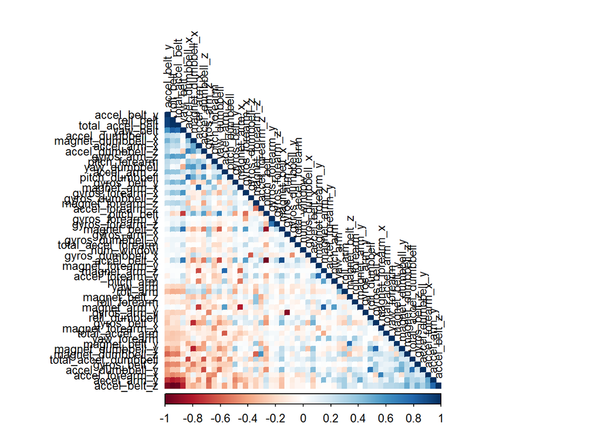

```r
corrplot(cor(train[,-54]),order="FPC",method = "color", type = "lower",tl.cex = 0.8, tl.col = rgb(0, 0, 0))
```

We see there are a few variables that correlate. However, since these are only few I didn’t proceed with the Principal Component Analysis.

### Model Building

I will be applying 3 models: 1. Random Forest 2. Decision Tree 3. Generalized Boosted Model and will be comparing their accuracy. The best model will be used to predict the validation set.

### Random Forest Model

```r
set.seed(2468)
ctrl<- trainControl(method="cv", number=3, verboseIter=FALSE)
Fit.rf <- train(classe ~ ., data=train, method="rf",trControl=ctrl)

#Random Forest Model
Fit.rf$finalModel
```

```
##
## Call:
##  randomForest(x = x, y = y, mtry = param$mtry)
##                Type of random forest: classification
##                      Number of trees: 500
## No. of variables tried at each split: 27
##
##         OOB estimate of  error rate: 0.2%
## Confusion matrix:
##      A    B    C    D    E class.error
## A 3906    0    0    0    0 0.000000000
## B    6 2648    3    1    0 0.003762227
## C    0    5 2391    0    0 0.002086811
## D    0    0    9 2242    1 0.004440497
## E    0    1    0    2 2522 0.001188119
```

```r
#Prediction
pred.rf<-predict(Fit.rf,newdata=test)
conf.mat.rf<-confusionMatrix(pred.rf,test$classe)
a.rf<-conf.mat.rf$overall[1]
conf.mat.rf$overall[1]
```

```
##  Accuracy
## 0.9976211
```

### Decision Tree

```r
set.seed(2468)
Fit.dt <- rpart(classe ~ ., data=train, method="class")

#Prediction
pred.dt<-predict(Fit.dt,newdata=test, type="class")
conf.mat.dt<-confusionMatrix(pred.dt,test$classe)
a.dt<-conf.mat.dt$overall[1]
conf.mat.dt$overall[1]
```

```
##  Accuracy
## 0.7685641
```

### Generalized Boosted Model

```r
set.seed(12345)
ctrl<- trainControl(method = "repeatedcv", number = 5, repeats = 1)
Fit.gbm<- train(classe ~ ., data=train, method = "gbm",trControl = ctrl, verbose = FALSE)
#Generalized Boosted Model
Fit.gbm$finalModel
```

```
## A gradient boosted model with multinomial loss function.
## 150 iterations were performed.
## There were 53 predictors of which 39 had non-zero influence.
```

```r
#Prediction
pred.gbm <- predict(Fit.gbm, newdata=test)
conf.mat.gbm <- confusionMatrix(pred.gbm, test$classe)
a.gbm<-conf.mat.gbm$overall[1]
conf.mat.gbm$overall[1]
```

```
##  Accuracy
## 0.9869159
```

### Results and Final Prediction

Off the 3 models, Random Forest had the highest accuracy with 0.9976211. Therefore, I made use of the random forest model on the validation set.

```r
pred.validation<-predict(Fit.rf,newdata=validation)
pred.validation
```

```
##  [1] B A B A A E D B A A B C B A E E A B B B
## Levels: A B C D E
```